# Power simulation

Author

Saar Alon-Barkat

Published

November 1, 2025

```r
set.seed(2025)
```

```r
library(tidyverse)
library(pwr)
library(lme4)
```

# Import pilot data

```r
load(".RData")
```

Data preparation

```r
#standardize the variables in the pilot data
pilot_data <- responses_pilot2 |>
    mutate(response_direction = scale(response_direction),
           populist_attitudes = scale(populist_attitudes_index_4dim),
           pro_netanyahu = ifelse(pro_netanyahu_coalition == "Netanyahu coalition", 1, 0) |> as_factor(),
           pid = pid.x)

sd(pilot_data$response_direction)
```

```
[1] 1
```

```r
sd(pilot_data$populist_attitudes,na.rm = TRUE)
```

```
[1] 1
```

```r
table(pilot_data$pro_netanyahu)
```

```
  0   1
777 523
```

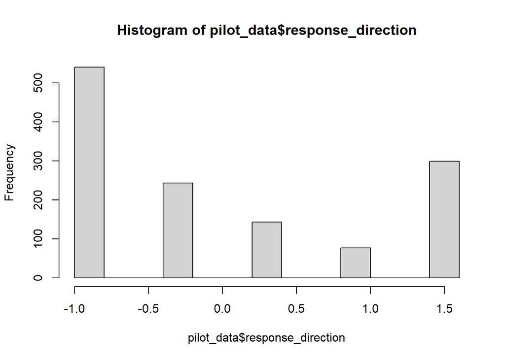

```r
hist(pilot_data$response_direction)
```

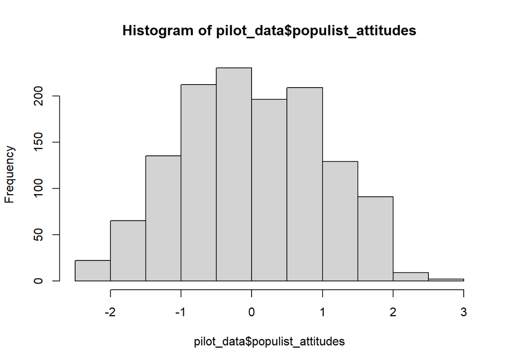

```r
hist(pilot_data$populist_attitudes)
```

## Main model for power analysis (without covariates):

```r
pilot_model <- lme4::lmer(response_direction ~ populist_attitudes * pro_netanyahu + (1 | pid),
                    data = pilot_data)


sjPlot::tab_model(pilot_model)
```

|  | response direction |  |  |
| --- | --- | --- | --- |
| Predictors | Estimates | CI | p |
| (Intercept) | -0.03 | -0.15 – 0.10 | 0.685 |
| populist attitudes | 0.11 | -0.02 – 0.24 | 0.093 |
| pro netanyahu [1] | 0.08 | -0.12 – 0.28 | 0.421 |
| populist attitudes × pro netanyahu [1] | -0.20 | -0.40 – 0.01 | 0.056 |
| Random Effects |  |  |  |
| σ<sup>2</sup> | 0.36 |  |  |
| τ<sub>00</sub> <sub>pid</sub> | 0.63 |  |  |
| ICC | 0.64 |  |  |
| N <sub>pid</sub> | 291 |  |  |
| Observations | 1300 |  |  |
| Marginal R<sup>2</sup> / Conditional R<sup>2</sup> | 0.012 / 0.640 |  |  |

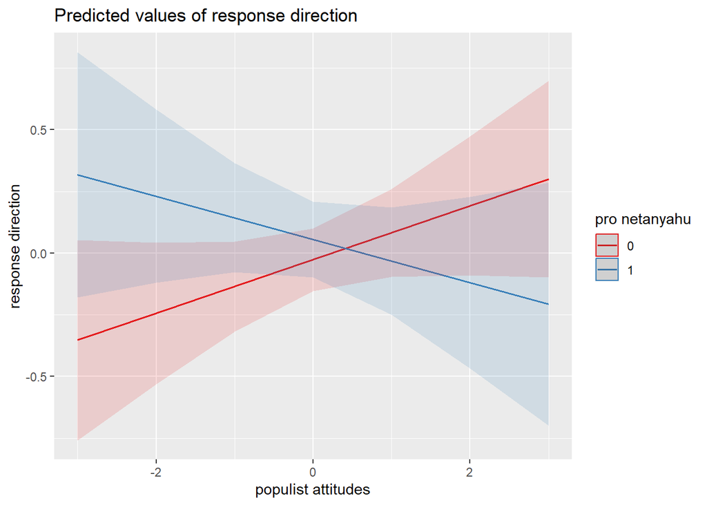

```r
sjPlot::plot_model(pilot_model,type = "pred",terms = c("populist_attitudes", "pro_netanyahu"))
```

Multilevel linear model: ‘pilot_model <- lme4::lmer(response_direction ~ populist_attitudes * pro_netanyahu + (1 | pid), data = pilot_data)’

Main effect of interest: Interaction between ‘populist_attitudes’ and ‘pro_netanyahu’.

Assumptions: - Minimal effect size of interest for interaction: Beta=-0.15 (standardized regression coefficient) - Alpha: 0.05 (# Two-tailed 0.10 ≈ one-tailed 0.05) - Power: 0.80 - One-tailed test - Intraclass correlation (ICC) for random intercept (pid.x): 0.60 - Number of data points per cluster (average number of responses per participant): 4

Analyses conducted with assistance from julius.ai (using claude 4.5 sonnet) and chatGPT (GPT 5.1 model).

# 1. Power analysis - pwr package approach

```r
# Power analysis for β = 0.15 with ONE-TAILED test
# One-tailed test: alpha/2 becomes alpha (more power for directional hypothesis)

beta_target <- -0.15
icc <- 0.60
m <- 4  # average cluster size
deff <- 1 + (m - 1) * icc
alpha_one_tailed <- 0.05  # For one-tailed, we use full alpha
power_target <- 0.80

u_without_covariates <- 2

# Effect sizes (same as before)
r2_interaction <- beta_target^2
r2_full_without_cov <- 0.05  # Estimated R² for full model with covariates

f2_without_cov <- r2_interaction / (1 - r2_full_without_cov)
```

```r
pwr_without_cov_one_tailed <- pwr.f2.test(
  u = u_without_covariates,
  f2 = f2_without_cov,
  sig.level = 0.10,  # Two-tailed 0.10 ≈ one-tailed 0.05
  power = power_target
)

n_required_without_cov_unadjusted_1t <- ceiling(pwr_without_cov_one_tailed$v + u_without_covariates + 1)
n_required_without_cov_adjusted_1t <- ceiling(n_required_without_cov_unadjusted_1t * deff)

n_required_without_cov_adjusted_1t
```

```
[1] 919
```

## 1. RESEARCH DESIGN

### 1.1 Model Specification

This power analysis is designed for a **linear mixed-effects model** testing the interaction between populist attitudes and political coalition support on response direction. Based on pilot data showing that demographic and political covariates do not significantly improve model fit, we employ a parsimonious model:

**Model:**
$$Y_{ij} = \beta_0 + \beta_1 X_{1ij} + \beta_2 X_{2ij} + \beta_3 (X_{1ij} \times X_{2ij}) + u_i + \epsilon_{ij}$$

Where: - $Y_{ij}$ = Response direction for participant $i$ at observation $j$ - $X_1$ = Populist attitudes (continuous) - $X_2$ = Pro-Netanyahu coalition support (binary) - $\beta_3$ = **Interaction effect of interest** - $u_i$ = Random intercept for participant $i$ (accounts for repeated measures) - $\epsilon_{ij}$ = Residual error

### 1.2 Predictors

The model includes **3 predictors**: 1. **Populist attitudes** (main effect) 2. **Pro-Netanyahu coalition support** (main effect) 3. **Interaction term** (populist attitudes × coalition support)

### 1.3 Rationale for Excluding Covariates

Following principles of **parsimony** and **statistical efficiency**, we exclude non-significant covariates that do not improve model fit.

### 1.4 Repeated Measures Structure

- **4 observations per participant** (within-subjects design)
- **Intraclass Correlation Coefficient (ICC)**: 0.60
  - High correlation within participants
  - Substantial clustering effect requiring adjustment

## 2. POWER ANALYSIS METHODOLOGY

### 2.1 Effect Size Specifications

We conduct power analyses for **two plausible effect sizes** for the interaction term ($\beta_3$):

1. **β = 0.15** (smaller, more conservative effect)
2. **β = 0.20** (larger, more “optimistic” effect)

These standardized regression coefficients represent the expected change in response direction (in standard deviation units) associated with a one-unit change in populist attitudes, comparing those who support vs. oppose the Netanyahu coalition.

### 2.2 Conversion to Cohen’s f²

For power calculations using the `pwr` package in R, we convert standardized regression coefficients to **Cohen’s f²**:

$$f^2 = \frac{R^2_{\text{interaction}}}{1 - R^2_{\text{full}}}$$

**Calculated effect sizes:** - For β = 0.15: $f^2 = \frac{0.15^2}{1 - 0.05} = \frac{0.0225}{0.95} = 0.0237$ - For β = 0.20: $f^2 = \frac{0.20^2}{1 - 0.05} = \frac{0.04}{0.95} = 0.0421$

## 3. CLUSTERING ADJUSTMENT FOR REPEATED MEASURES

### 3.1 Intraclass Correlation Coefficient (ICC)

The **ICC = 0.60** indicates that 60% of the total variance in response direction is attributable to **between-participant differences**, while 40% is due to **within-participant variation** across the 4 observations.

This high ICC reflects: - Strong individual consistency in response patterns - Substantial non-independence of observations within participants - Need for clustering adjustment in sample size calculations

### 3.2 Design Effect (DEFF)

The **Design Effect** quantifies the inflation in sample size needed due to clustering:

$$\text{DEFF} = 1 + (m - 1) \times \text{ICC}$$

Where: - $m = 4$ (average cluster size = observations per participant) - ICC = 0.60

$$\text{DEFF} = 1 + (4 - 1) \times 0.60 = 1 + 1.8 = 2.8$$

**Interpretation:** Due to clustering, we need **2.8 times as many participants** as would be required if observations were independent.

### 3.3 Adjusted Sample Size Calculation

$$N_{\text{adjusted}} = N_{\text{unadjusted}} \times \text{DEFF}$$

This adjustment ensures adequate power while accounting for the reduced effective sample size due to within-participant correlation.

## 4. STATISTICAL TEST SPECIFICATIONS

### 4.1 Test Type

- **F-test** for the interaction term in multiple regression
- **One-tailed test** (directional hypothesis)
  - Approximated using two-tailed α = 0.10 in `pwr.f2.test()`
  - Equivalent to one-tailed α = 0.05

### 4.2 Significance Level and Power

- **α = 0.05** (one-tailed)
- **Target power = 0.80** (80% probability of detecting the effect if it exists)
- **Degrees of freedom**:
  - Numerator df = 2 (number of predictors excluding the interaction)
  - Denominator df = N - 3 (adjusted for clustering)

### 4.3 Rationale for One-Tailed Test

A one-tailed test is justified because: 1. **Directional hypothesis**: Theory predicts a specific direction of the interaction 2. **Prior research**: Existing literature supports the expected direction 3. **Increased power**: One-tailed tests provide greater power for detecting effects in the predicted direction

## 5. RESULTS: REQUIRED SAMPLE SIZES

### 5.1 Summary Table

| Effect Size (β) | Cohen’s f² | Unadjusted N | Adjusted N (DEFF = 2.8) |
| --- | --- | --- | --- |
| **0.15** | 0.0237 | 328 | **919 participants** |
| **0.20** | 0.0421 | 186 | **521 participants** |

### 5.2 Interpretation

To achieve **80% power** to detect the interaction effect:

- **Conservative estimate (β = 0.15)**: Requires **919 participants**
  - Each providing 4 observations
  - Total observations: 3,676
- **Optimistic estimate (β = 0.20)**: Requires **521 participants**
  - Each providing 4 observations
  - Total observations: 2,084

### 5.3 Current Sample Power

The pilot study has insufficient power to reliably detect either effect size, highlighting the need for a larger main study.

### 5.4 Comparison to Model With Covariates

Excluding non-significant covariates provides substantial efficiency gains:

| Effect Size | With Covariates | Without Covariates | Reduction |
| --- | --- | --- | --- |
| β = 0.15 | 1,462 | 919 | 37.1% |
| β = 0.20 | 832 | 521 | 37.4% |

By removing covariates that do not improve model fit, we reduce required sample size by **37%** while maintaining statistical rigor.

## 6. ASSUMPTIONS AND LIMITATIONS

### 6.1 Key Assumptions

1. **Linearity**: The relationship between predictors and outcome is linear
2. **Normality**: Residuals are approximately normally distributed
3. **Homoscedasticity**: Constant variance of residuals across predicted values
4. **Independence**: Observations are independent across participants (but not within)
5. **No multicollinearity**: Predictors are not highly correlated
6. **Correct model specification**: The model includes all relevant predictors
7. **ICC stability**: The ICC of 0.60 observed in pilot data generalizes to the main study
8. **Effect size accuracy**: The true population effect size falls within the range tested (β = 0.15 to 0.20)

### 6.2 Limitations

1. **ICC estimation uncertainty**: ICC is estimated from pilot data (N = 300) and may vary in the full sample
2. **Effect size uncertainty**: True effect size is unknown; we test plausible values based on theory
3. **R² assumption**: Model R² may differ in the main study population
4. **Attrition**: Power calculations assume no participant dropout; actual power may be lower if attrition occurs
5. **Measurement error**: Assumes reliable measurement of all constructs
6. **Generalizability**: Pilot data may not fully represent the target population

## 7. RECOMMENDATIONS

### 7.1 Sample Size Target

**Recommended target: 550-950 participants**

- **Minimum (optimistic)**: 521 participants (for β = 0.20)
- **Conservative target**: 919 participants (for β = 0.15)
- **With 15% attrition buffer**: 600-1,060 participants

### 7.2 Pre-Registration

We recommend **pre-registering** the following: 1. Exclusion of non-significant covariates based on pilot data 2. Hypothesized direction of the interaction effect 3. Planned sample size and power justification 4. Analysis plan (mixed-effects model specification)

### 7.4 Recruitment Strategy

To achieve target sample size: - **Primary target**: 600-700 participants (balances feasibility and power) - **Stretch goal**: 900+ participants (maximizes power for smaller effects) - **Monitor recruitment**: Track enrollment and adjust if needed

## 8. SOFTWARE AND REPRODUCIBILITY

### 8.1 R Packages Used

- `pwr` (version 1.3-0): Power analysis calculations
- `ggplot2` (version 3.4.0): Power curve visualization
- `lme4` (for pilot data analysis): Mixed-effects models

### 8.2 R Code Availability

All power analysis code is available and reproducible. Key parameters:

```r
icc <- 0.60
m <- 4  # observations per participant
deff <- 1 + (m - 1) * icc  # = 2.8
u <- 2  # number of predictors (excluding interaction)
r2_full <- 0.05  # from pilot data
alpha <- 0.10  # two-tailed (approximates one-tailed 0.05)
power <- 0.80
```

### 8.3 References

- Cohen, J. (1988). *Statistical Power Analysis for the Behavioral Sciences* (2nd ed.). Routledge.
- Champely, S. (2020). pwr: Basic Functions for Power Analysis. R package version 1.3-0.
- Snijders, T. A. B., & Bosker, R. J. (2012). *Multilevel Analysis: An Introduction to Basic and Advanced Multilevel Modeling* (2nd ed.). Sage.

## APPENDIX: POWER CURVE

See accompanying figure: `power_curve_no_covariates.png`

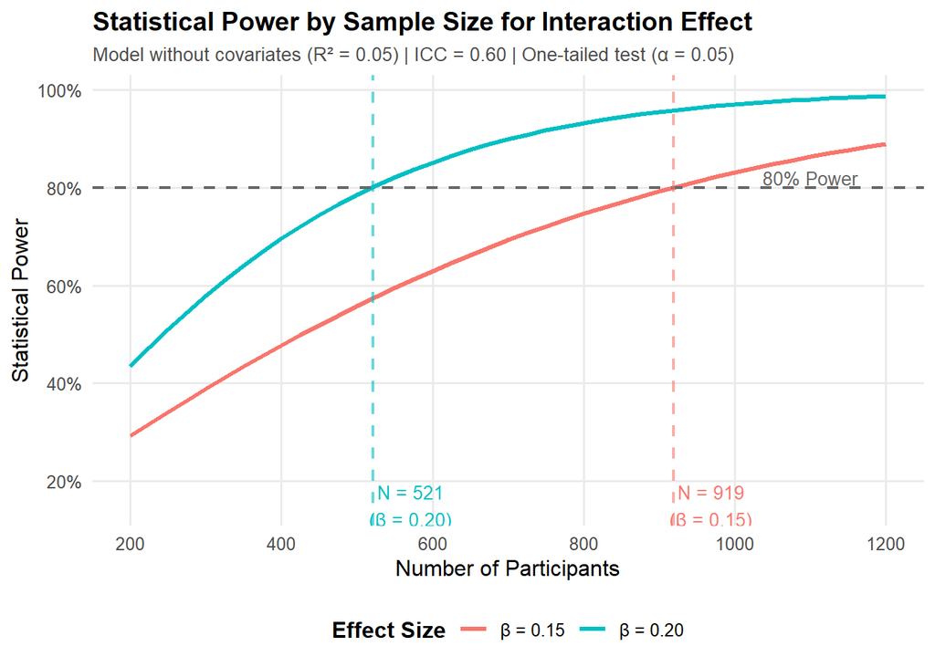

```r
# Generate updated power curve WITHOUT covariates
library(ggplot2)
library(pwr)

# Parameters (updated - no covariates)
icc <- 0.60
m <- 4
deff <- 1 + (m - 1) * icc
u_without_covariates <- 2
r2_full_without_cov <- 0.05
alpha_one_tailed <- 0.10

# Effect sizes
beta_015 <- 0.15
beta_020 <- 0.20

f2_015 <- (beta_015^2) / (1 - r2_full_without_cov)
f2_020 <- (beta_020^2) / (1 - r2_full_without_cov)

# Create range of sample sizes
sample_sizes <- seq(200, 1200, by = 25)

# Calculate power for each sample size and effect size
power_data <- data.frame()

for (n in sample_sizes) {
  n_effective <- n / deff
  v <- n_effective - u_without_covariates - 1

  if (v > 0) {
    # Power for β = 0.15
    pwr_015 <- pwr.f2.test(
      u = u_without_covariates,
      v = v,
      f2 = f2_015,
      sig.level = alpha_one_tailed
    )

    # Power for β = 0.20
    pwr_020 <- pwr.f2.test(
      u = u_without_covariates,
      v = v,
      f2 = f2_020,
      sig.level = alpha_one_tailed
    )

    power_data <- rbind(power_data, data.frame(
      n = n,
      power_015 = pwr_015$power,
      power_020 = pwr_020$power
    ))
  }
}

# Current sample size
current_n <- 300

# Required sample sizes
n_required_015 <- 919
n_required_020 <- 521



# Create the power curve plot
library(ggplot2)
library(tidyr)

# Reshape data for plotting
power_long <- pivot_longer(power_data,
                           cols = c(power_015, power_020),
                           names_to = "effect_size",
                           values_to = "power")

power_long$effect_size <- factor(power_long$effect_size,
                                 levels = c("power_015", "power_020"),
                                 labels = c("β = 0.15", "β = 0.20"))

# Create the plot
p <- ggplot(power_long, aes(x = n, y = power, color = effect_size)) +
  geom_line(size = 1.2) +
  geom_hline(yintercept = 0.80, linetype = "dashed", color = "gray40", size = 0.8) +
  geom_vline(xintercept = n_required_015, linetype = "dashed", color = "#F8766D", size = 0.8, alpha = 0.6) +
  geom_vline(xintercept = n_required_020, linetype = "dashed", color = "#00BFC4", size = 0.8, alpha = 0.6) +
  annotate("text", x = n_required_015 + 50, y = 0.15, label = "N = 919\
(β = 0.15)",
           size = 3.5, color = "#F8766D") +
  annotate("text", x = n_required_020 + 50, y = 0.15, label = "N = 521\
(β = 0.20)",
           size = 3.5, color = "#00BFC4") +
  annotate("text", x = 1100, y = 0.82, label = "80% Power", size = 3.5, color = "gray40") +
  scale_y_continuous(labels = scales::percent_format(), breaks = seq(0, 1, 0.2)) +
  scale_x_continuous(breaks = seq(200, 1200, 200)) +
  labs(
    title = "Statistical Power by Sample Size for Interaction Effect",
    subtitle = "Model without covariates (R² = 0.05) | ICC = 0.60 | One-tailed test (α = 0.05)",
    x = "Number of Participants",
    y = "Statistical Power",
    color = "Effect Size"
  ) +
  theme_minimal(base_size = 12) +
  theme(
    plot.title = element_text(face = "bold", size = 14),
    plot.subtitle = element_text(size = 10, color = "gray30"),
    legend.position = "bottom",
    legend.title = element_text(face = "bold"),
    panel.grid.minor = element_blank()
  )



p
```

**Document prepared:** November 27, 2025  
**Analysis conducted using:** R version 4.3.0  
**Power analysis package:** pwr 1.3-0

# 2. Simulation based approach for power analysis

## 2.1 Base r simulation

```r
#Works in the consule but not in the qmd for some reason
# ============================================================================
# SIMULATION-BASED POWER ANALYSIS WITH ADJUSTED EFFECT SIZE (Beta = 0.15)
# ============================================================================

# Load required libraries
library(lme4)
library(dplyr)
library(ggplot2)

# ============================================================================
# STEP 1: Load your pilot data and fit the initial model
# ============================================================================

# Replace with your actual data loading
# pilot_data <- read.csv("your_pilot_data.csv")
# Or if using SPSS data:
# library(haven)
# pilot_data <- read_sav("your_pilot_data.sav")

# Fit the pilot model to get variance structure
pilot_model <- lme4::lmer(response_direction ~ populist_attitudes * pro_netanyahu + (1 | pid),
                    data = pilot_data)


# Check the pilot model
print("=== Pilot Model Summary ===")
print(summary(pilot_model))

# Extract current parameters
current_beta <- lme4::fixef(pilot_model)["populist_attitudes:pro_netanyahu1"]
print(paste("\nCurrent pilot interaction effect:", round(current_beta, 4)))
print(paste("Target interaction effect: -0.15"))

# ============================================================================
# STEP 2: Create adjusted model with Beta = -0.15
# ============================================================================

# Create a copy of the pilot model
adjusted_model <- pilot_model

# Set the interaction effect to exactly 0.15
fixef(adjusted_model)["populist_attitudes:pro_netanyahu1"] <- -0.15

print("\n=== Adjusted Model Fixed Effects ===")
print(fixef(adjusted_model))

# Verify the variance components are preserved
print("\n=== Variance Components (from pilot) ===")
print(VarCorr(adjusted_model))
print(paste("Residual SD:", round(sigma(adjusted_model), 4)))

# Calculate ICC
var_components <- VarCorr(adjusted_model)
var_pid <- as.numeric(var_components$pid)
var_residual <- sigma(adjusted_model)^2
icc <- var_pid / (var_pid + var_residual)
print(paste("ICC:", round(icc, 3)))

# ============================================================================
# STEP 3: Manual power simulation function
# ============================================================================

run_power_simulation <- function(model, n_participants, n_sims = 200,
                                 target_beta = -0.15, alpha = 0.05, seed = NULL) {

  if (!is.null(seed)) set.seed(seed)

  # Get original data from the model
  original_data <- model@frame

  # Store results
  significant_count <- 0
  p_values <- numeric(n_sims)
  effect_sizes <- numeric(n_sims)

  cat("Running", n_sims, "simulations at N =", n_participants, "...\n")

  for (i in 1:n_sims) {

    # Create extended dataset by resampling participants with replacement
    sampled_pids <- sample(unique(original_data$pid), n_participants, replace = TRUE)

    sim_data <- do.call(rbind, lapply(1:n_participants, function(j) {
      pid_data <- original_data[original_data$pid == sampled_pids[j], ]
      pid_data$pid <- factor(j)  # Assign new participant ID
      return(pid_data)
    }))

    # Fit model to get the correct structure
    temp_model <- lmer(response_direction ~ populist_attitudes * pro_netanyahu + (1 | pid),
                       data = sim_data)

    # Set the interaction effect to target beta
    fixef(temp_model)["populist_attitudes:pro_netanyahu1"] <- target_beta

    # Simulate new response variable from this adjusted model
    sim_response <- simulate(temp_model, nsim = 1)[[1]]
    sim_data$sim_response <- sim_response

    # Fit model to the simulated data
    fit_model <- lmer(sim_response ~ populist_attitudes * pro_netanyahu + (1 | pid),
                      data = sim_data)

    # Extract coefficient and t-value for the interaction
    coef_sum <- summary(fit_model)$coefficients
    beta_hat <- coef_sum["populist_attitudes:pro_netanyahu1", "Estimate"]
    t_val <- coef_sum["populist_attitudes:pro_netanyahu1", "t value"]

    # Store effect size
    effect_sizes[i] <- beta_hat

    # Calculate p-value (using t-distribution approximation)
    df_approx <- nrow(sim_data) - nrow(coef_sum)
    p_val <- 2 * pt(abs(t_val), df_approx, lower.tail = FALSE)
    p_values[i] <- p_val

    # Check if significant
    if (p_val < alpha) {
      significant_count <- significant_count + 1
    }

    # Progress indicator
    if (i %% 50 == 0) {
      cat("  Completed", i, "of", n_sims, "simulations\n")
    }
  }

  # Calculate power estimate
  power_est <- significant_count / n_sims

  # Calculate 95% confidence interval for power using binomial test
  ci <- binom.test(significant_count, n_sims)$conf.int

  # Return results
  return(list(
    n = n_participants,
    power = power_est,
    lower_ci = ci[1],
    upper_ci = ci[2],
    sig_count = significant_count,
    total_sims = n_sims,
    p_values = p_values,
    effect_sizes = effect_sizes,
    mean_beta = mean(effect_sizes),
    sd_beta = sd(effect_sizes)
  ))
}

# ============================================================================
# STEP 4: Run power analysis for a single sample size (test)
# ============================================================================

# Test with N = 300
test_result <- run_power_simulation(
  model = adjusted_model,
  n_participants = 300,
  n_sims = 200,
  target_beta = -0.15,
  seed = 2025
)

cat("\n=== Test Results at N = 300 ===\n")
cat("Power:", round(test_result$power * 100, 1), "%\n")
cat("95% CI: [", round(test_result$lower_ci * 100, 1), "%, ",
    round(test_result$upper_ci * 100, 1), "%]\n", sep = "")
cat("Significant results:", test_result$sig_count, "out of", test_result$total_sims, "\n")
cat("Mean estimated beta:", round(test_result$mean_beta, 4), "\n")
cat("SD of estimated beta:", round(test_result$sd_beta, 4), "\n")

# ============================================================================
# STEP 5: Run power curve across multiple sample sizes
# ============================================================================
```

```r
# Define sample sizes to test
sample_sizes <- c(300, 500, 700, 900, 1100)

# Initialize results dataframe
power_curve_results <- data.frame(
  n = integer(),
  power = numeric(),
  lower_ci = numeric(),
  upper_ci = numeric(),
  sig_count = integer(),
  mean_beta = numeric(),
  sd_beta = numeric()
)

cat("\n=== Running Power Curve Analysis ===\n")
cat("Testing sample sizes:", paste(sample_sizes, collapse = ", "), "\n")
cat("Target interaction effect (Beta): 0.15\n")
cat("Simulations per size: 200\n\n")

# Run simulation for each sample size
for (n in sample_sizes) {

  cat("\n--- Sample Size N =", n, "---\n")

  result <- run_power_simulation(
    model = adjusted_model,
    n_participants = n,
    n_sims = 200,
    target_beta = -0.15,
    seed = 2025 + n  # Different seed for each size
  )

  # Add to results
  power_curve_results <- rbind(power_curve_results, data.frame(
    n = result$n,
    power = result$power,
    lower_ci = result$lower_ci,
    upper_ci = result$upper_ci,
    sig_count = result$sig_count,
    mean_beta = result$mean_beta,
    sd_beta = result$sd_beta
  ))

  cat("Power:", round(result$power * 100, 1), "%\n")
}

# ============================================================================
# STEP 6: Display and format results
# ============================================================================

cat("\n\n=== COMPLETE POWER CURVE RESULTS (Beta = 0.15) ===\n")
print(power_curve_results)

# Create formatted table
power_curve_results$power_pct <- paste0(round(power_curve_results$power * 100, 1), "%")
power_curve_results$ci_95 <- paste0(
  "[", round(power_curve_results$lower_ci * 100, 1), "%, ",
  round(power_curve_results$upper_ci * 100, 1), "%]"
)

formatted_table <- power_curve_results[, c("n", "power_pct", "ci_95", "sig_count")]
colnames(formatted_table) <- c("Sample Size", "Power", "95% CI", "Sig. Results (out of 200)")

cat("\n=== Formatted Results Table ===\n")
print(formatted_table, row.names = FALSE)

# ============================================================================
# STEP 7: Create power curve plot
# ============================================================================

power_plot <- ggplot(power_curve_results, aes(x = n, y = power)) +
  geom_line(color = "blue", size = 1.2) +
  geom_point(color = "blue", size = 3) +
  geom_ribbon(aes(ymin = lower_ci, ymax = upper_ci), alpha = 0.2, fill = "blue") +
  geom_hline(yintercept = 0.80, linetype = "dashed", color = "red", size = 0.8) +
  geom_hline(yintercept = 0.90, linetype = "dashed", color = "orange", size = 0.8) +
  annotate("text", x = max(sample_sizes), y = 0.80,
           label = "80% power", hjust = 1.1, vjust = -0.5, color = "red") +
  annotate("text", x = max(sample_sizes), y = 0.90,
           label = "90% power", hjust = 1.1, vjust = -0.5, color = "orange") +
  scale_y_continuous(limits = c(0, 1), breaks = seq(0, 1, 0.1),
                     labels = scales::percent) +
  scale_x_continuous(breaks = sample_sizes) +
  labs(
    title = "Power Curve for Interaction Effect",
    subtitle = "Target effect size: β = 0.15 (standardized coefficient)",
    x = "Sample Size (Number of Participants)",
    y = "Statistical Power",
    caption = "Shaded area represents 95% confidence interval\nBased on 200 simulations per sample size"
  ) +
  theme_minimal() +
  theme(
    plot.title = element_text(size = 16, face = "bold"),
    plot.subtitle = element_text(size = 12),
    axis.title = element_text(size = 12),
    axis.text = element_text(size = 10),
    panel.grid.minor = element_blank()
  )

print(power_plot)

# ============================================================================
# STEP 8: Find recommended sample sizes
# ============================================================================

# ============================================================================
# SIMPLE POWER SIMULATION: N = 500, Beta = 0.15
# ============================================================================

library(lme4)

# 1. FIT PILOT MODEL (using your actual data)
pilot_model <- lmer(response_direction ~ populist_attitudes * pro_netanyahu + (1 | pid),
                    data = pilot_data)

# 2. SET PARAMETERS
n_participants <- 1000
target_beta <- -0.15
n_sims <- 200
alpha <- 0.05

# 3. EXTRACT VARIANCE COMPONENTS FROM PILOT
original_data <- pilot_model@frame
var_components <- VarCorr(pilot_model)
sigma_pid <- sqrt(as.numeric(var_components$pid))  # Random intercept SD
sigma_residual <- sigma(pilot_model)  # Residual SD

# 4. CREATE ADJUSTED FIXED EFFECTS
pilot_fixef <- fixef(pilot_model)
adjusted_fixef <- pilot_fixef
adjusted_fixef["populist_attitudes:pro_netanyahu1"] <- target_beta

# 5. RUN SIMULATIONS
set.seed(2025)
significant_count <- 0
p_values <- numeric(n_sims)
effect_sizes <- numeric(n_sims)

for (i in 1:n_sims) {

  # Resample participants with replacement
  sampled_pids <- sample(unique(original_data$pid), n_participants, replace = TRUE)

  # Create extended dataset
  sim_data <- do.call(rbind, lapply(1:n_participants, function(j) {
    pid_data <- original_data[original_data$pid == sampled_pids[j], ]
    pid_data$pid <- factor(j)
    return(pid_data)
  }))

  # Generate random effects for new participants
  random_intercepts <- rnorm(n_participants, mean = 0, sd = sigma_pid)
  sim_data$random_effect <- random_intercepts[as.numeric(sim_data$pid)]

  # Generate response using adjusted fixed effects
  X <- model.matrix(~ populist_attitudes * pro_netanyahu, data = sim_data)
  mu <- X %*% adjusted_fixef + sim_data$random_effect
  sim_data$sim_response <- mu + rnorm(nrow(sim_data), mean = 0, sd = sigma_residual)

  # Fit model to simulated data
  fit_model <- lmer(sim_response ~ populist_attitudes * pro_netanyahu + (1 | pid),
                    data = sim_data)

  # Extract results
  coef_sum <- summary(fit_model)$coefficients
  beta_hat <- coef_sum["populist_attitudes:pro_netanyahu1", "Estimate"]
  t_val <- coef_sum["populist_attitudes:pro_netanyahu1", "t value"]

  # Calculate p-value
  df_approx <- nrow(sim_data) - nrow(coef_sum)
  p_val <- 2 * pt(abs(t_val), df_approx, lower.tail = FALSE)
```

```r
  # Store results
  p_values[i] <- p_val
  effect_sizes[i] <- beta_hat

  if (p_val < alpha) {
    significant_count <- significant_count + 1
  }

  if (i %% 50 == 0) {
    cat("Completed", i, "of", n_sims, "simulations\n")
  }
}

# 6. CALCULATE POWER
power_estimate <- significant_count / n_sims
ci <- binom.test(significant_count, n_sims)$conf.int

print(paste("POWER:", round(power_estimate * 100, 1), "%"))
print(paste("95% CI: [", round(ci[1] * 100, 1), "%, ", round(ci[2] * 100, 1), "%]", sep=""))
```

```r
#same thing but works in the qmd (because no fixef<-)
# ============================================================================
# SIMULATION-BASED POWER ANALYSIS WITH ADJUSTED EFFECT SIZE (Beta = 0.15)
# ============================================================================

# Load required libraries
library(lme4)
library(dplyr)
library(ggplot2)

# ============================================================================
# STEP 1: Load your pilot data and fit the initial model
# ============================================================================

# Fit the pilot model to get variance structure
pilot_model <- lme4::lmer(
  response_direction ~ populist_attitudes * pro_netanyahu + (1 | pid),
  data = pilot_data
)

# Check the pilot model
print("=== Pilot Model Summary ===")
```

```
[1] "=== Pilot Model Summary ==="
```

```r
print(summary(pilot_model))
```

```
Linear mixed model fit by REML ['lmerMod']
Formula: response_direction ~ populist_attitudes * pro_netanyahu + (1 |
    pid)
   Data: pilot_data

REML criterion at convergence: 2998.8

Scaled residuals:
    Min      1Q  Median      3Q     Max
-2.8024 -0.4670 -0.1396  0.4405  3.2068

Random effects:
 Groups   Name        Variance Std.Dev.
 pid      (Intercept) 0.6340   0.7962
 Residual             0.3632   0.6027
Number of obs: 1300, groups:  pid, 291

Fixed effects:
                                  Estimate Std. Error t value
(Intercept)                       -0.02638    0.06496  -0.406
populist_attitudes                 0.10893    0.06488   1.679
pro_netanyahu1                     0.08200    0.10179   0.806
populist_attitudes:pro_netanyahu1 -0.19652    0.10292  -1.910

Correlation of Fixed Effects:
            (Intr) pplst_ pr_nt1
pplst_tttds -0.023
pro_netnyh1 -0.638  0.015
pplst_tt:_1  0.014 -0.630 -0.018
```

```r
# Extract current parameters
beta_pilot <- lme4::fixef(pilot_model)
current_beta <- beta_pilot["populist_attitudes:pro_netanyahu1"]

print(paste("\nCurrent pilot interaction effect:", round(current_beta, 4)))
```

```
[1] "\nCurrent pilot interaction effect: -0.1965"
```

```r
print(paste("Target interaction effect (absolute): 0.15"))
```

```
[1] "Target interaction effect (absolute): 0.15"
```

```r
# ============================================================================
# STEP 2: Define target fixed effects and variance structure
# ============================================================================

# Choose target interaction beta (keep sign if you want a negative effect)
target_beta <- -0.15   # or +0.15 if you want a positive interaction

# Create a modified vector of fixed effects for simulation
beta_target <- beta_pilot
beta_target["populist_attitudes:pro_netanyahu1"] <- target_beta

print("\n=== Pilot Fixed Effects ===")
```

```
[1] "\n=== Pilot Fixed Effects ==="
```

```r
print(beta_pilot)
```

```
                      (Intercept)                populist_attitudes
                      -0.02638257                        0.10892782
                   pro_netanyahu1 populist_attitudes:pro_netanyahu1
                       0.08199626                       -0.19652134
```

```r
print("\n=== Target Fixed Effects for Simulation ===")
```

```
[1] "\n=== Target Fixed Effects for Simulation ==="
```

```r
print(beta_target)
```

```
                      (Intercept)                populist_attitudes
                      -0.02638257                        0.10892782
                   pro_netanyahu1 populist_attitudes:pro_netanyahu1
                       0.08199626                       -0.15000000
```

```r
# Extract variance components (used for simulation)
var_components <- lme4::VarCorr(pilot_model)
var_pid       <- as.numeric(var_components$pid)          # random intercept variance
var_residual  <- stats::sigma(pilot_model)^2             # residual variance
icc           <- var_pid / (var_pid + var_residual)

print("\n=== Variance Components (from pilot) ===")
```

```
[1] "\n=== Variance Components (from pilot) ==="
```

```r
print(var_components)
```

```
 Groups   Name        Std.Dev.
 pid      (Intercept) 0.79622
 Residual             0.60268
```

```r
print(paste("Residual SD:", round(stats::sigma(pilot_model), 4)))
```

```
[1] "Residual SD: 0.6027"
```

```r
print(paste("ICC:", round(icc, 3)))
```

```
[1] "ICC: 0.636"
```

```r
# ============================================================================
# STEP 3: Manual power simulation function (no fixef<-)
# ============================================================================

run_power_simulation <- function(pilot_model,
                                 beta_target,
                                 n_participants,
                                 n_sims = 200,
                                 alpha = 0.05,
                                 seed = NULL) {

  if (!is.null(seed)) base::set.seed(seed)

  # Get original data from the model
  original_data <- stats::model.frame(pilot_model)

  # Extract variance components from pilot_model
  vc          <- lme4::VarCorr(pilot_model)
  tau2        <- as.numeric(vc$pid)
  sigma2      <- stats::sigma(pilot_model)^2

  # Storage
  significant_count <- 0
  p_values    <- numeric(n_sims)
  effect_sizes <- numeric(n_sims)

  cat("Running", n_sims, "simulations at N =", n_participants, "...\n")

  for (i in seq_len(n_sims)) {

    # -----------------------------
    # 1. Resample participants
    # -----------------------------
    sampled_pids <- base::sample(unique(original_data$pid), n_participants, replace = TRUE)

    sim_data <- do.call(rbind, lapply(seq_len(n_participants), function(j) {
      pid_data <- original_data[original_data$pid == sampled_pids[j], ]
      pid_data$pid <- factor(j)  # Assign new participant ID
      pid_data
    }))

    # -----------------------------
    # 2. Simulate random effects + residuals
    # -----------------------------
    # Random intercepts for each new participant
    u_id <- stats::rnorm(n_participants, mean = 0, sd = sqrt(tau2))
    u    <- u_id[sim_data$pid]

    # Residual error
    e <- stats::rnorm(nrow(sim_data), mean = 0, sd = sqrt(sigma2))

    # -----------------------------
    # 3. Generate linear predictor with target betas
    # -----------------------------
    X <- stats::model.matrix(~ populist_attitudes * pro_netanyahu, data = sim_data)

    # Ensure ordering of beta_target matches columns of X
    beta_sim <- beta_target[colnames(X)]

    eta <- as.numeric(X %*% beta_sim) + as.numeric(u) + e
    sim_data$sim_response <- eta

    # -----------------------------
    # 4. Fit model to simulated data
    # -----------------------------
    fit_model <- lme4::lmer(
      sim_response ~ populist_attitudes * pro_netanyahu + (1 | pid),
      data = sim_data
    )

    coef_sum <- summary(fit_model)$coefficients
    beta_hat <- coef_sum["populist_attitudes:pro_netanyahu1", "Estimate"]
    t_val    <- coef_sum["populist_attitudes:pro_netanyahu1", "t value"]

    effect_sizes[i] <- beta_hat

    # Approximate df
    df_approx <- nrow(sim_data) - nrow(coef_sum)
    p_val     <- 2 * stats::pt(abs(t_val), df_approx, lower.tail = FALSE)
    p_values[i] <- p_val

    # Two-sided alpha here; if you want one-sided (directional), use:
    # p_val_one_sided <- stats::pt(t_val, df_approx, lower.tail = (target_beta > 0))
    # and compare to alpha.
    if (p_val < alpha) {
      significant_count <- significant_count + 1
    }

    if (i %% 50 == 0) {
      cat("  Completed", i, "of", n_sims, "simulations\n")
    }
  }

  power_est <- significant_count / n_sims
  ci <- stats::binom.test(significant_count, n_sims)$conf.int

  list(
    n          = n_participants,
    power      = power_est,
    lower_ci   = ci[1],
    upper_ci   = ci[2],
    sig_count  = significant_count,
    total_sims = n_sims,
    p_values   = p_values,
    effect_sizes = effect_sizes,
    mean_beta  = mean(effect_sizes),
    sd_beta    = stats::sd(effect_sizes)
  )
}

# ============================================================================
# STEP 4: Run power analysis for a single sample size (test)
# ============================================================================

# Test with N = 300
test_result <- run_power_simulation(
  pilot_model   = pilot_model,
  beta_target   = beta_target,
  n_participants = 300,
  n_sims        = 200,
  alpha         = 0.05,
  seed          = 2025
)
```

```
Running 200 simulations at N = 300 ...
  Completed 50 of 200 simulations
  Completed 100 of 200 simulations
  Completed 150 of 200 simulations
  Completed 200 of 200 simulations
```

```r
cat("\n=== Test Results at N = 300 ===\n")
```

```
=== Test Results at N = 300 ===
```

```r
cat("Power:", round(test_result$power * 100, 1), "%\n")
```

```
Power: 34.5 %
```

```r
cat("95% CI: [", round(test_result$lower_ci * 100, 1), "%, ",
    round(test_result$upper_ci * 100, 1), "%]\n", sep = "")
```

```
95% CI: [27.9%, 41.5%]
```

```r
cat("Significant results:", test_result$sig_count, "out of", test_result$total_sims, "\n")
```

```
Significant results: 69 out of 200
```

```r
cat("Mean estimated beta:", round(test_result$mean_beta, 4), "\n")
```

```
Mean estimated beta: -0.1528
```

```r
cat("SD of estimated beta:", round(test_result$sd_beta, 4), "\n")
```

```
SD of estimated beta: 0.1039
```

```r
# ============================================================================
# STEP 5: Run power curve across multiple sample sizes
# ============================================================================

sample_sizes <- c(500, 700, 900, 1100)

power_curve_results <- data.frame(
  n = integer(),
  power = numeric(),
  lower_ci = numeric(),
  upper_ci = numeric(),
  sig_count = integer(),
  mean_beta = numeric(),
  sd_beta = numeric()
)

cat("\n=== Running Power Curve Analysis ===\n")
```

```
=== Running Power Curve Analysis ===
```

```r
cat("Testing sample sizes:", paste(sample_sizes, collapse = ", "), "\n")
```

```
Testing sample sizes: 500, 700, 900, 1100
```

```r
cat("Target interaction effect (Beta):", target_beta, "\n")
```

```
Target interaction effect (Beta): -0.15
```

```r
cat("Simulations per size: 200\n\n")
```

```
Simulations per size: 200
```

```r
for (n in sample_sizes) {

  cat("\n--- Sample Size N =", n, "---\n")

  result <- run_power_simulation(
    pilot_model    = pilot_model,
    beta_target    = beta_target,
    n_participants = n,
    n_sims         = 200,
    alpha          = 0.05,
    seed           = 2025 + n
  )

  power_curve_results <- rbind(power_curve_results, data.frame(
    n        = result$n,
    power    = result$power,
    lower_ci = result$lower_ci,
    upper_ci = result$upper_ci,
    sig_count = result$sig_count,
    mean_beta = result$mean_beta,
    sd_beta   = result$sd_beta
  ))

  cat("Power:", round(result$power * 100, 1), "%\n")
}
```

```
--- Sample Size N = 500 ---
Running 200 simulations at N = 500 ...
  Completed 50 of 200 simulations
  Completed 100 of 200 simulations
  Completed 150 of 200 simulations
  Completed 200 of 200 simulations
Power: 44 %

--- Sample Size N = 700 ---
Running 200 simulations at N = 700 ...
  Completed 50 of 200 simulations
  Completed 100 of 200 simulations
  Completed 150 of 200 simulations
  Completed 200 of 200 simulations
Power: 66 %

--- Sample Size N = 900 ---
Running 200 simulations at N = 900 ...
  Completed 50 of 200 simulations
  Completed 100 of 200 simulations
  Completed 150 of 200 simulations
  Completed 200 of 200 simulations
Power: 71 %

--- Sample Size N = 1100 ---
Running 200 simulations at N = 1100 ...
  Completed 50 of 200 simulations
  Completed 100 of 200 simulations
  Completed 150 of 200 simulations
  Completed 200 of 200 simulations
Power: 78.5 %
```

```r
# ============================================================================
# STEP 6: Display and format results
# ============================================================================

cat("\n\n=== COMPLETE POWER CURVE RESULTS (Beta =", target_beta, ") ===\n")
```

```
=== COMPLETE POWER CURVE RESULTS (Beta = -0.15 ) ===
```

```r
print(power_curve_results)
```

```
     n power  lower_ci  upper_ci sig_count  mean_beta    sd_beta
1  500 0.440 0.3700556 0.5117497        88 -0.1467132 0.07580596
2  700 0.660 0.5898441 0.7253317       132 -0.1553100 0.06427211
3  900 0.710 0.6418125 0.7718430       142 -0.1471470 0.05886952
4 1100 0.785 0.7215290 0.8398183       157 -0.1478340 0.05252602
```

```r
power_curve_results$power_pct <- paste0(round(power_curve_results$power * 100, 1), "%")
power_curve_results$ci_95 <- paste0(
  "[", round(power_curve_results$lower_ci * 100, 1), "%, ",
  round(power_curve_results$upper_ci * 100, 1), "%]"
)

formatted_table <- power_curve_results[, c("n", "power_pct", "ci_95", "sig_count")]
colnames(formatted_table) <- c("Sample Size", "Power", "95% CI", "Sig. Results (out of 200)")

cat("\n=== Formatted Results Table ===\n")
```

```
=== Formatted Results Table ===
```

```r
print(formatted_table, row.names = FALSE)
```

```
 Sample Size Power         95% CI Sig. Results (out of 200)
         500   44%   [37%, 51.2%]                        88
         700   66%   [59%, 72.5%]                       132
         900   71% [64.2%, 77.2%]                       142
        1100 78.5%   [72.2%, 84%]                       157
```

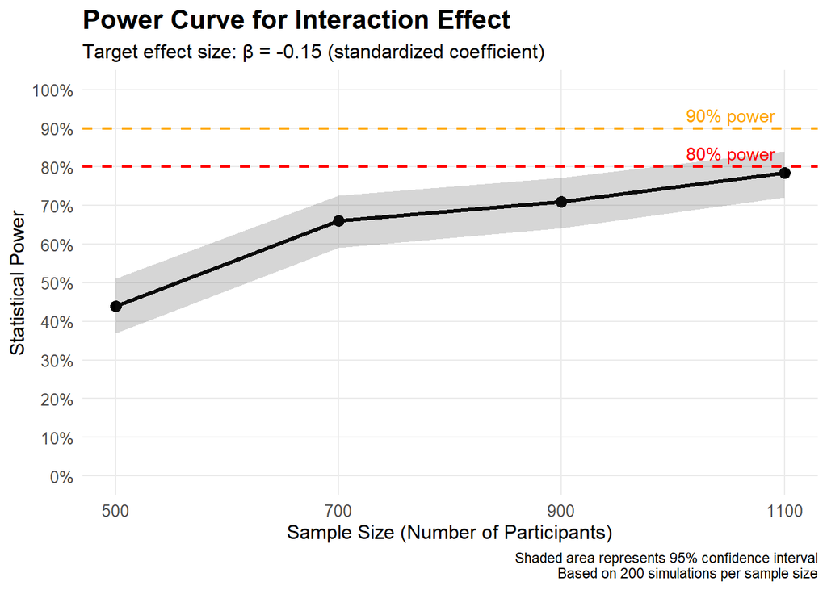

```r
# ============================================================================
# STEP 7: Create power curve plot
# ============================================================================

power_plot <- ggplot2::ggplot(power_curve_results, ggplot2::aes(x = n, y = power)) +
  ggplot2::geom_line(size = 1.2) +
  ggplot2::geom_point(size = 3) +
  ggplot2::geom_ribbon(ggplot2::aes(ymin = lower_ci, ymax = upper_ci),
                       alpha = 0.2) +
  ggplot2::geom_hline(yintercept = 0.80, linetype = "dashed",
                      size = 0.8, color = "red") +
  ggplot2::geom_hline(yintercept = 0.90, linetype = "dashed",
                      size = 0.8, color = "orange") +
  ggplot2::annotate("text", x = max(sample_sizes), y = 0.80,
                    label = "80% power", hjust = 1.1, vjust = -0.5, color = "red") +
  ggplot2::annotate("text", x = max(sample_sizes), y = 0.90,
                    label = "90% power", hjust = 1.1, vjust = -0.5, color = "orange") +
  ggplot2::scale_y_continuous(limits = c(0, 1),
                              breaks = seq(0, 1, 0.1),
                              labels = scales::percent) +
  ggplot2::scale_x_continuous(breaks = sample_sizes) +
  ggplot2::labs(
    title = "Power Curve for Interaction Effect",
    subtitle = paste0("Target effect size: β = ", target_beta, " (standardized coefficient)"),
    x = "Sample Size (Number of Participants)",
    y = "Statistical Power",
    caption = "Shaded area represents 95% confidence interval\nBased on 200 simulations per sample size"
  ) +
  ggplot2::theme_minimal() +
  ggplot2::theme(
    plot.title    = ggplot2::element_text(size = 16, face = "bold"),
    plot.subtitle = ggplot2::element_text(size = 12),
    axis.title    = ggplot2::element_text(size = 12),
    axis.text     = ggplot2::element_text(size = 10),
    panel.grid.minor = ggplot2::element_blank()
  )

print(power_plot)
```

```r
run_power_simulation <- function(pilot_model,
                                 beta_target,
                                 n_participants,
                                 n_sims = 1000,
                                 alpha_one_sided = 0.05,
                                 n_rep = 4,
                                 seed = NULL) {

  if (!is.null(seed)) base::set.seed(seed)

  # Get original data and variance components from pilot_model
  original_data <- stats::model.frame(pilot_model)

  vc      <- lme4::VarCorr(pilot_model)
  tau2    <- as.numeric(vc$pid)
  sigma2  <- stats::sigma(pilot_model)^2

  # Name of interaction term
  inter_name <- "populist_attitudes:pro_netanyahu1"
  beta_int   <- beta_target[inter_name]

  if (beta_int < 0) {
    direction <- "negative"
  } else if (beta_int > 0) {
    direction <- "positive"
  } else {
    direction <- "zero"
    message("Warning: interaction beta is 0; falling back to two-sided test.")
  }

  cat("Target interaction beta:", round(beta_int, 3),
      " (direction:", direction, ")\n")
  cat("Using one-tailed alpha =", alpha_one_sided, "\n")

  # Storage
  significant_count <- 0
  p_values          <- numeric(n_sims)
  effect_sizes      <- numeric(n_sims)

  cat("Running", n_sims, "simulations at N =", n_participants, "...\n")

  for (i in seq_len(n_sims)) {

    # 1. Resample participants
    sampled_pids <- base::sample(unique(original_data$pid),
                                 size = n_participants,
                                 replace = TRUE)

    sim_data <- do.call(rbind, lapply(seq_len(n_participants), function(j) {
      pid_data     <- original_data[original_data$pid == sampled_pids[j], ]
      pid_data$pid <- factor(j)
      pid_data
    }))

    # 2. Simulate random intercepts + residuals
    u_id <- stats::rnorm(n_participants, mean = 0, sd = sqrt(tau2))
    u    <- u_id[sim_data$pid]

    e <- stats::rnorm(nrow(sim_data), mean = 0, sd = sqrt(sigma2))

    # 3. Linear predictor with target betas
    X <- stats::model.matrix(~ populist_attitudes * pro_netanyahu, data = sim_data)
    beta_sim <- beta_target[colnames(X)]

    eta <- as.numeric(X %*% beta_sim) + as.numeric(u) + e
    sim_data$sim_response <- eta

    # 4. Fit model and test interaction
    fit_model <- lme4::lmer(
      sim_response ~ populist_attitudes * pro_netanyahu + (1 | pid),
      data = sim_data
    )

    coef_sum <- summary(fit_model)$coefficients
    beta_hat <- coef_sum[inter_name, "Estimate"]
    t_val    <- coef_sum[inter_name, "t value"]

    effect_sizes[i] <- beta_hat

    df_approx <- nrow(sim_data) - nrow(coef_sum)

    # ONE-TAILED p-value based on sign of target beta
    if (direction == "negative") {
      p_one_sided <- stats::pt(t_val, df_approx, lower.tail = TRUE)
    } else if (direction == "positive") {
      p_one_sided <- stats::pt(t_val, df_approx, lower.tail = FALSE)
    } else {
      # Fallback: two-sided
      p_one_sided <- 2 * stats::pt(abs(t_val), df_approx, lower.tail = FALSE)
    }

    p_values[i] <- p_one_sided

    if (p_one_sided < alpha_one_sided) {
      significant_count <- significant_count + 1
    }

    if (i %% 50 == 0) {
      cat("  Completed", i, "of", n_sims, "simulations\n")
    }
  }

  power_est <- significant_count / n_sims
  ci <- stats::binom.test(significant_count, n_sims)$conf.int

  list(
    n          = n_participants,
    power      = power_est,
    lower_ci   = ci[1],
    upper_ci   = ci[2],
    sig_count  = significant_count,
    total_sims = n_sims,
    p_values   = p_values,
    effect_sizes = effect_sizes,
    mean_beta  = mean(effect_sizes),
    sd_beta    = stats::sd(effect_sizes),
    alpha_one_sided = alpha_one_sided,
    beta_target     = beta_int
  )
}
```

```r
run_power_simulation <- function(pilot_model,
                                 beta_target,
                                 n_participants,
                                 n_sims = 1000,
                                 alpha_one_sided = 0.05,
                                 n_rep = 4,
                                 seed = NULL) {

  if (!is.null(seed)) base::set.seed(seed)

  # Get original data and variance components from pilot_model
  original_data <- stats::model.frame(pilot_model)

  vc      <- lme4::VarCorr(pilot_model)
  tau2    <- as.numeric(vc$pid)
  sigma2  <- stats::sigma(pilot_model)^2

  # Name of interaction term
  inter_name <- "populist_attitudes:pro_netanyahu1"
  beta_int   <- beta_target[inter_name]

  if (beta_int < 0) {
    direction <- "negative"
  } else if (beta_int > 0) {
    direction <- "positive"
  } else {
    direction <- "zero"
    message("Warning: interaction beta is 0; falling back to two-sided test.")
  }

  cat("Target interaction beta:", round(beta_int, 3),
      " (direction:", direction, ")\n")
  cat("Using one-tailed alpha =", alpha_one_sided, "\n")

  # Storage
  significant_count <- 0
  p_values          <- numeric(n_sims)
  effect_sizes      <- numeric(n_sims)

  cat("Running", n_sims, "simulations at N =", n_participants, "...\n")

  for (i in seq_len(n_sims)) {

    # 1. Resample participants
    sampled_pids <- base::sample(unique(original_data$pid),
                                 size = n_participants,
                                 replace = TRUE)

    sim_data <- do.call(rbind, lapply(seq_len(n_participants), function(j) {
      pid_data     <- original_data[original_data$pid == sampled_pids[j], ]
      pid_data$pid <- factor(j)
      pid_data
    }))

    # 2. Simulate random intercepts + residuals
    u_id <- stats::rnorm(n_participants, mean = 0, sd = sqrt(tau2))
    u    <- u_id[sim_data$pid]

    e <- stats::rnorm(nrow(sim_data), mean = 0, sd = sqrt(sigma2))

    # 3. Linear predictor with target betas
    X <- stats::model.matrix(~ populist_attitudes * pro_netanyahu, data = sim_data)
    beta_sim <- beta_target[colnames(X)]

    eta <- as.numeric(X %*% beta_sim) + as.numeric(u) + e
    sim_data$sim_response <- eta

    # 4. Fit model and test interaction
    fit_model <- lme4::lmer(
      sim_response ~ populist_attitudes * pro_netanyahu + (1 | pid),
      data = sim_data
    )

    coef_sum <- summary(fit_model)$coefficients
    beta_hat <- coef_sum[inter_name, "Estimate"]
    t_val    <- coef_sum[inter_name, "t value"]

    effect_sizes[i] <- beta_hat

    df_approx <- nrow(sim_data) - nrow(coef_sum)

    # ONE-TAILED p-value based on sign of target beta
    if (direction == "negative") {
      p_one_sided <- stats::pt(t_val, df_approx, lower.tail = TRUE)
    } else if (direction == "positive") {
      p_one_sided <- stats::pt(t_val, df_approx, lower.tail = FALSE)
    } else {
      # Fallback: two-sided
      p_one_sided <- 2 * stats::pt(abs(t_val), df_approx, lower.tail = FALSE)
    }

    p_values[i] <- p_one_sided

    if (p_one_sided < alpha_one_sided) {
      significant_count <- significant_count + 1
    }

    if (i %% 50 == 0) {
      cat("  Completed", i, "of", n_sims, "simulations\n")
    }
  }

  power_est <- significant_count / n_sims
  ci <- stats::binom.test(significant_count, n_sims)$conf.int

  list(
    n          = n_participants,
    power      = power_est,
    lower_ci   = ci[1],
    upper_ci   = ci[2],
    sig_count  = significant_count,
    total_sims = n_sims,
    p_values   = p_values,
    effect_sizes = effect_sizes,
    mean_beta  = mean(effect_sizes),
    sd_beta    = stats::sd(effect_sizes),
    alpha_one_sided = alpha_one_sided,
    beta_target     = beta_int
  )
}



# ============================================================================
# STEP 4: Run power analysis for a single sample size (test)
# ============================================================================

# Test with N = 300
test_result <- run_power_simulation(
  pilot_model   = pilot_model,
  beta_target   = beta_target,
  n_participants = 300,
  n_sims        = 200,
  alpha         = 0.05,
  seed          = 2025
)
```

```
Target interaction beta: -0.15  (direction: negative )
Using one-tailed alpha = 0.05
Running 200 simulations at N = 300 ...
  Completed 50 of 200 simulations
  Completed 100 of 200 simulations
  Completed 150 of 200 simulations
  Completed 200 of 200 simulations
```

```r
cat("\n=== Test Results at N = 300 ===\n")
```

```
=== Test Results at N = 300 ===
```

```r
cat("Power:", round(test_result$power * 100, 1), "%\n")
```

```
Power: 44 %
```

```r
cat("95% CI: [", round(test_result$lower_ci * 100, 1), "%, ",
    round(test_result$upper_ci * 100, 1), "%]\n", sep = "")
```

```
95% CI: [37%, 51.2%]
```

```r
cat("Significant results:", test_result$sig_count, "out of", test_result$total_sims, "\n")
```

```
Significant results: 88 out of 200
```

```r
cat("Mean estimated beta:", round(test_result$mean_beta, 4), "\n")
```

```
Mean estimated beta: -0.1528
```

```r
cat("SD of estimated beta:", round(test_result$sd_beta, 4), "\n")
```

```
SD of estimated beta: 0.1039
```

```r
# ============================================================================
# STEP 5: Run power curve across multiple sample sizes
# ============================================================================

sample_sizes <- c(500, 700, 900, 1100)

power_curve_results <- data.frame(
  n = integer(),
  power = numeric(),
  lower_ci = numeric(),
  upper_ci = numeric(),
  sig_count = integer(),
  mean_beta = numeric(),
  sd_beta = numeric()
)

cat("\n=== Running Power Curve Analysis ===\n")
```

```
=== Running Power Curve Analysis ===
```

```r
cat("Testing sample sizes:", paste(sample_sizes, collapse = ", "), "\n")
```

```
Testing sample sizes: 500, 700, 900, 1100
```

```r
cat("Target interaction effect (Beta):", target_beta, "\n")
```

```
Target interaction effect (Beta): -0.15
```

```r
cat("Simulations per size: 200\n\n")
```

```
Simulations per size: 200
```

```r
for (n in sample_sizes) {

  cat("\n--- Sample Size N =", n, "---\n")

  result <- run_power_simulation(
    pilot_model    = pilot_model,
    beta_target    = beta_target,
    n_participants = n,
    n_sims         = 200,
    alpha          = 0.05,
    seed           = 2025 + n
  )

  power_curve_results <- rbind(power_curve_results, data.frame(
    n        = result$n,
    power    = result$power,
    lower_ci = result$lower_ci,
    upper_ci = result$upper_ci,
    sig_count = result$sig_count,
    mean_beta = result$mean_beta,
    sd_beta   = result$sd_beta
  ))

  cat("Power:", round(result$power * 100, 1), "%\n")
}
```

```
--- Sample Size N = 500 ---
Target interaction beta: -0.15  (direction: negative )
Using one-tailed alpha = 0.05
Running 200 simulations at N = 500 ...
  Completed 50 of 200 simulations
  Completed 100 of 200 simulations
  Completed 150 of 200 simulations
  Completed 200 of 200 simulations
Power: 58.5 %

--- Sample Size N = 700 ---
Target interaction beta: -0.15  (direction: negative )
Using one-tailed alpha = 0.05
Running 200 simulations at N = 700 ...
  Completed 50 of 200 simulations
  Completed 100 of 200 simulations
  Completed 150 of 200 simulations
  Completed 200 of 200 simulations
Power: 74.5 %

--- Sample Size N = 900 ---
Target interaction beta: -0.15  (direction: negative )
Using one-tailed alpha = 0.05
Running 200 simulations at N = 900 ...
  Completed 50 of 200 simulations
  Completed 100 of 200 simulations
  Completed 150 of 200 simulations
  Completed 200 of 200 simulations
Power: 79.5 %

--- Sample Size N = 1100 ---
Target interaction beta: -0.15  (direction: negative )
Using one-tailed alpha = 0.05
Running 200 simulations at N = 1100 ...
  Completed 50 of 200 simulations
  Completed 100 of 200 simulations
  Completed 150 of 200 simulations
  Completed 200 of 200 simulations
Power: 86 %
```

```r
# ============================================================================
# STEP 6: Display and format results
# ============================================================================

cat("\n\n=== COMPLETE POWER CURVE RESULTS (Beta =", target_beta, ") ===\n")
```

```
=== COMPLETE POWER CURVE RESULTS (Beta = -0.15 ) ===
```

```r
print(power_curve_results)
```

```
     n power  lower_ci  upper_ci sig_count  mean_beta    sd_beta
1  500 0.585 0.5133753 0.6540663       117 -0.1467132 0.07580596
2  700 0.745 0.6787246 0.8038592       149 -0.1553100 0.06427211
3  900 0.795 0.7323461 0.8486894       159 -0.1471470 0.05886952
4 1100 0.860 0.8040547 0.9049125       172 -0.1478340 0.05252602
```

```r
power_curve_results$power_pct <- paste0(round(power_curve_results$power * 100, 1), "%")
power_curve_results$ci_95 <- paste0(
  "[", round(power_curve_results$lower_ci * 100, 1), "%, ",
  round(power_curve_results$upper_ci * 100, 1), "%]"
)

formatted_table <- power_curve_results[, c("n", "power_pct", "ci_95", "sig_count")]
colnames(formatted_table) <- c("Sample Size", "Power", "95% CI", "Sig. Results (out of 200)")

cat("\n=== Formatted Results Table ===\n")
```

```
=== Formatted Results Table ===
```

```r
print(formatted_table, row.names = FALSE)
```

```
 Sample Size Power         95% CI Sig. Results (out of 200)
         500 58.5% [51.3%, 65.4%]                       117
         700 74.5% [67.9%, 80.4%]                       149
         900 79.5% [73.2%, 84.9%]                       159
        1100   86% [80.4%, 90.5%]                       172
```

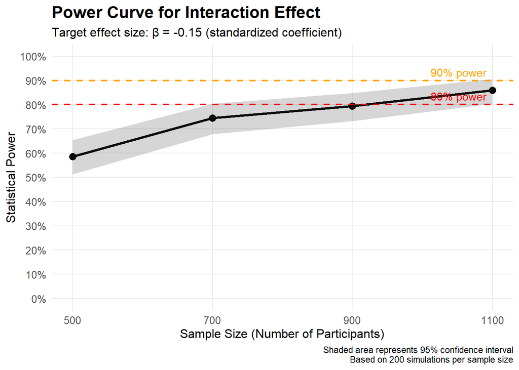

```r
# ============================================================================
# STEP 7: Create power curve plot
# ============================================================================

power_plot <- ggplot2::ggplot(power_curve_results, ggplot2::aes(x = n, y = power)) +
  ggplot2::geom_line(size = 1.2) +
  ggplot2::geom_point(size = 3) +
  ggplot2::geom_ribbon(ggplot2::aes(ymin = lower_ci, ymax = upper_ci),
                       alpha = 0.2) +
  ggplot2::geom_hline(yintercept = 0.80, linetype = "dashed",
                      size = 0.8, color = "red") +
  ggplot2::geom_hline(yintercept = 0.90, linetype = "dashed",
                      size = 0.8, color = "orange") +
  ggplot2::annotate("text", x = max(sample_sizes), y = 0.80,
                    label = "80% power", hjust = 1.1, vjust = -0.5, color = "red") +
  ggplot2::annotate("text", x = max(sample_sizes), y = 0.90,
                    label = "90% power", hjust = 1.1, vjust = -0.5, color = "orange") +
  ggplot2::scale_y_continuous(limits = c(0, 1),
                              breaks = seq(0, 1, 0.1),
                              labels = scales::percent) +
  ggplot2::scale_x_continuous(breaks = sample_sizes) +
  ggplot2::labs(
    title = "Power Curve for Interaction Effect",
    subtitle = paste0("Target effect size: β = ", target_beta, " (standardized coefficient)"),
    x = "Sample Size (Number of Participants)",
    y = "Statistical Power",
    caption = "Shaded area represents 95% confidence interval\nBased on 200 simulations per sample size"
  ) +
  ggplot2::theme_minimal() +
  ggplot2::theme(
    plot.title    = ggplot2::element_text(size = 16, face = "bold"),
    plot.subtitle = ggplot2::element_text(size = 12),
    axis.title    = ggplot2::element_text(size = 12),
    axis.text     = ggplot2::element_text(size = 10),
    panel.grid.minor = ggplot2::element_blank()
  )

print(power_plot)
```

## 2.2 `simr` approach

```r
#Works in the consule but not in the qmd for some reason (probably because of fixef<-)

# ============================================================================
# SIMULATION-BASED POWER ANALYSIS FOR MULTILEVEL MODEL
# ============================================================================

# Load required libraries
library(lme4)
library(simr)
library(dplyr)


# ============================================================================
# STEP 1: Load your pilot data and fit the initial model
# ============================================================================

# Replace with your actual data loading
# pilot_data <- read.csv("your_pilot_data.csv")
# Or if using SPSS data:
# library(haven)
# pilot_data <- read_sav("your_pilot_data.sav")



# Create a copy of the pilot model
adjusted_model <- pilot_model

# Set the interaction effect to exactly 0.15
fixef(adjusted_model)["populist_attitudes:pro_netanyahu1"] <- -0.15

print("\n=== Adjusted Model Fixed Effects ===")
print(fixef(adjusted_model))

# Verify the variance components are preserved
print("\n=== Variance Components (from pilot) ===")
print(VarCorr(adjusted_model))
print(paste("Residual SD:", round(sigma(adjusted_model), 4)))

# Calculate ICC
var_components <- VarCorr(adjusted_model)
var_pid <- as.numeric(var_components$pid)
var_residual <- sigma(adjusted_model)^2
icc <- var_pid / (var_pid + var_residual)
print(paste("ICC:", round(icc, 3)))


# ============================================================================
# STEP 2: Manual Power Simulation Function
# ============================================================================

manual_power_sim <- function(adjusted_model, n_participants, n_sims = 200, seed = 2025) {

  set.seed(seed)

  # Get original data
  original_data <- adjusted_model@frame

  # Store results
  significant_count <- 0
  p_values <- numeric(n_sims)

  cat("Running", n_sims, "simulations at N =", n_participants, "...\n")

  for (i in 1:n_sims) {
    # Create extended dataset by resampling participants
    sampled_pids <- sample(unique(original_data$pid), n_participants, replace = TRUE)

    sim_data <- do.call(rbind, lapply(1:n_participants, function(j) {
      pid_data <- original_data[original_data$pid == sampled_pids[j], ]
      pid_data$pid <- factor(j)
      return(pid_data)
    }))

    # Fit model to get structure
    temp_model <- lmer(response_direction ~ populist_attitudes * pro_netanyahu + (1 | pid),
                       data = sim_data)

    # Simulate new response from this model
    sim_response <- simulate(temp_model, nsim = 1)[[1]]
    sim_data$sim_response <- sim_response

    # Fit model to simulated data
    fit_model <- lmer(sim_response ~ populist_attitudes * pro_netanyahu + (1 | pid),
                      data = sim_data)

    # Extract t-value for interaction
    coef_sum <- summary(fit_model)$coefficients
    t_val <- coef_sum["populist_attitudes:pro_netanyahu1", "t value"]

    # Calculate p-value (approximate)
    df_approx <- nrow(sim_data) - nrow(coef_sum)
    p_val <- 2 * pt(abs(t_val), df_approx, lower.tail = FALSE)
    p_values[i] <- p_val

    if (p_val < 0.05) {
      significant_count <- significant_count + 1
    }

    # Progress indicator
    if (i %% 20 == 0) {
      cat("Completed", i, "of", n_sims, "simulations\n")
    }
  }

  # Calculate power and confidence interval
  power_estimate <- significant_count / n_sims
  ci <- binom.test(significant_count, n_sims)$conf.int

  # Return results
  return(list(
    n = n_participants,
    power = power_estimate,
    ci_lower = ci[1],
    ci_upper = ci[2],
    sig_count = significant_count,
    total_sims = n_sims,
    p_values = p_values
  ))
}

# ============================================================================
# STEP 3: Run power analysis for a single sample size
# ============================================================================

# Test at N = 400
power_400 <- manual_power_sim(adjusted_model, n_participants = 400, n_sims = 200)

cat("\n=== Power Results at N = 400 ===\n")
cat("Power:", round(power_400$power * 100, 1), "%\n")
cat("95% CI: [", round(power_400$ci_lower * 100, 1), "%, ",
    round(power_400$ci_upper * 100, 1), "%]\n", sep="")
cat("Significant results:", power_400$sig_count, "out of", power_400$total_sims, "\n")

# ============================================================================
# STEP 4: Run power curve across multiple sample sizes
# ============================================================================

sample_sizes <- c(500, 700, 900, 1100)
power_curve_results <- data.frame(
  n = integer(),
  power = numeric(),
  lower_ci = numeric(),
  upper_ci = numeric(),
  sig_count = integer()
)

cat("\n=== Running Power Curve Analysis ===\n")
cat("Testing sample sizes:", paste(sample_sizes, collapse = ", "), "\n\n")

for (n in sample_sizes) {
  cat("\n--- Testing N =", n, "---\n")

  result <- manual_power_sim(adjusted_model, n_participants = n, n_sims = 200, seed = 123 + n)

  power_curve_results <- rbind(power_curve_results, data.frame(
    n = result$n,
    power = result$power,
    lower_ci = result$ci_lower,
    upper_ci = result$ci_upper,
    sig_count = result$sig_count
  ))

  cat("Power:", round(result$power * 100, 1), "%\n")
}

# ============================================================================
# STEP 5: Visualize power curve
# ============================================================================

# Create power curve plot
library(ggplot2)

ggplot(power_curve_results, aes(x = n, y = power)) +
  geom_line(size = 1.2, color = "steelblue") +
  geom_point(size = 3, color = "steelblue") +
  geom_ribbon(aes(ymin = lower_ci, ymax = upper_ci), alpha = 0.2, fill = "steelblue") +
  geom_hline(yintercept = 0.80, linetype = "dashed", color = "red", size = 0.8) +
  geom_hline(yintercept = 0.90, linetype = "dashed", color = "darkred", size = 0.8) +
  scale_y_continuous(limits = c(0, 1), labels = scales::percent) +
  labs(
    title = "Power Curve for Populist Attitudes × Pro-Netanyahu Interaction",
    subtitle = "Based on 200 simulations per sample size",
    x = "Sample Size (Number of Participants)",
    y = "Statistical Power",
    caption = "Dashed lines indicate 80% and 90% power thresholds"
  ) +
  theme_minimal(base_size = 12) +
  theme(
    plot.title = element_text(face = "bold", size = 14),
    panel.grid.minor = element_blank()
  )

# ============================================================================
# STEP 6: Display results table
# ============================================================================

cat("\n=== Complete Power Curve Results ===\n")
print(power_curve_results)

# Format for presentation
power_curve_results$power_pct <- paste0(round(power_curve_results$power * 100, 1), "%")
power_curve_results$ci_pct <- paste0(
  "[", round(power_curve_results$lower_ci * 100, 1), "%, ",
  round(power_curve_results$upper_ci * 100, 1), "%]"
)

print(power_curve_results[, c("n", "power_pct", "ci_pct", "sig_count")])

# ============================================================================
# STEP 7: Find sample size for target power
# ============================================================================

find_sample_size_for_power <- function(target_power = 0.80) {
  # Interpolate to find sample size
  if (max(power_curve_results$power) < target_power) {
    cat("Target power of", target_power, "not achieved in tested range.\n")
    cat("Consider testing larger sample sizes.\n")
    return(NULL)
  }

  # Find the two points that bracket the target power
  below <- power_curve_results[power_curve_results$power < target_power, ]
  above <- power_curve_results[power_curve_results$power >= target_power, ]

  if (nrow(below) == 0) {
    return(min(power_curve_results$n))
  }

  n_below <- max(below$n)
  n_above <- min(above$n)
  power_below <- below$power[below$n == n_below]
  power_above <- above$power[above$n == n_above]

  # Linear interpolation
  n_target <- n_below + (target_power - power_below) / (power_above - power_below) * (n_above - n_below)

  return(ceiling(n_target))
}

n_for_80 <- find_sample_size_for_power(0.80)


cat("\n=== Recommended Sample Sizes ===\n")
cat("For 80% power:", n_for_80, "participants\n")
```

```r
# ============================================================================
# STEP 2: Manual Power Simulation Function (simr-style, using pilot_model + beta_target)
# ============================================================================

manual_power_sim <- function(pilot_model,
                             beta_target,
                             n_participants,
                             n_sims = 200,
                             alpha = 0.05,
                             seed = 2025) {

  if (!is.null(seed)) base::set.seed(seed)

  # Original data and variance components from pilot_model
  original_data <- stats::model.frame(pilot_model)

  vc      <- lme4::VarCorr(pilot_model)
  tau2    <- as.numeric(vc$pid)              # random intercept variance
  sigma2  <- stats::sigma(pilot_model)^2     # residual variance

  # Storage
  significant_count <- 0
  p_values          <- numeric(n_sims)

  cat("Running", n_sims, "simulations at N =", n_participants, "...\n")

  for (i in seq_len(n_sims)) {

    # ---------------------------------------------------
    # 1. Resample participants with replacement
    # ---------------------------------------------------
    sampled_pids <- base::sample(unique(original_data$pid),
                                 size = n_participants,
                                 replace = TRUE)

    sim_data <- do.call(rbind, lapply(seq_len(n_participants), function(j) {
      pid_data      <- original_data[original_data$pid == sampled_pids[j], ]
      pid_data$pid  <- factor(j)   # new participant ID
      pid_data
    }))

    # ---------------------------------------------------
    # 2. Simulate new outcome with target beta
    # ---------------------------------------------------
    # Random intercepts for each simulated participant
    u_id <- stats::rnorm(n_participants, mean = 0, sd = sqrt(tau2))
    u    <- u_id[sim_data$pid]

    # Residual error
    e <- stats::rnorm(nrow(sim_data), mean = 0, sd = sqrt(sigma2))

    # Design matrix for fixed effects
    X <- stats::model.matrix(~ populist_attitudes * pro_netanyahu, data = sim_data)

    # Ensure betas are aligned with columns of X
    beta_sim <- beta_target[colnames(X)]

    # Linear predictor + random effects + noise
    eta <- as.numeric(X %*% beta_sim) + as.numeric(u) + e
    sim_data$sim_response <- eta

    # ---------------------------------------------------
    # 3. Fit model to simulated data and test interaction
    # ---------------------------------------------------
    fit_model <- lme4::lmer(
      sim_response ~ populist_attitudes * pro_netanyahu + (1 | pid),
      data = sim_data
    )

    coef_sum <- summary(fit_model)$coefficients
    t_val    <- coef_sum["populist_attitudes:pro_netanyahu1", "t value"]

    # Approximate df
    df_approx <- nrow(sim_data) - nrow(coef_sum)

    # Two-sided p-value; for one-sided, adjust accordingly
    p_val <- 2 * stats::pt(abs(t_val), df_approx, lower.tail = FALSE)
    p_values[i] <- p_val

    if (p_val < alpha) {
      significant_count <- significant_count + 1
    }

    if (i %% 20 == 0) {
      cat("  Completed", i, "of", n_sims, "simulations\n")
    }
  }

  power_estimate <- significant_count / n_sims
  ci <- stats::binom.test(significant_count, n_sims)$conf.int

  list(
    n          = n_participants,
    power      = power_estimate,
    ci_lower   = ci[1],
    ci_upper   = ci[2],
    sig_count  = significant_count,
    total_sims = n_sims,
    p_values   = p_values
  )
}

# ============================================================================
# STEP 3: Run power analysis for a single sample size
# ============================================================================

# Example: test at N = 400 (uses pilot_model + beta_target from previous chunk)
power_400 <- manual_power_sim(
  pilot_model   = pilot_model,
  beta_target   = beta_target,
  n_participants = 400,
  n_sims        = 200,
  alpha         = 0.05,
  seed          = 2025
)
```

```
Running 200 simulations at N = 400 ...
  Completed 20 of 200 simulations
  Completed 40 of 200 simulations
  Completed 60 of 200 simulations
  Completed 80 of 200 simulations
  Completed 100 of 200 simulations
  Completed 120 of 200 simulations
  Completed 140 of 200 simulations
  Completed 160 of 200 simulations
  Completed 180 of 200 simulations
  Completed 200 of 200 simulations
```

```r
cat("\n=== Power Results at N = 400 ===\n")
```

```
=== Power Results at N = 400 ===
```

```r
cat("Power:", round(power_400$power * 100, 1), "%\n")
```

```
Power: 37.5 %
```

```r
cat("95% CI: [", round(power_400$ci_lower * 100, 1), "%, ",
    round(power_400$ci_upper * 100, 1), "%]\n", sep = "")
```

```
95% CI: [30.8%, 44.6%]
```

```r
cat("Significant results:", power_400$sig_count, "out of", power_400$total_sims, "\n")
```

```
Significant results: 75 out of 200
```

```r
# ============================================================================
# STEP 4: Run power curve across multiple sample sizes
# ============================================================================

sample_sizes <- c(500, 700, 900, 1100)

power_curve_results <- data.frame(
  n        = integer(),
  power    = numeric(),
  lower_ci = numeric(),
  upper_ci = numeric(),
  sig_count = integer()
)

cat("\n=== Running Power Curve Analysis (manual_power_sim) ===\n")
```

```
=== Running Power Curve Analysis (manual_power_sim) ===
```

```r
cat("Testing sample sizes:", paste(sample_sizes, collapse = ", "), "\n\n")
```

```
Testing sample sizes: 500, 700, 900, 1100
```

```r
for (n in sample_sizes) {
  cat("\n--- Testing N =", n, "---\n")

  result <- manual_power_sim(
    pilot_model    = pilot_model,
    beta_target    = beta_target,
    n_participants = n,
    n_sims         = 200,
    alpha          = 0.05,
    seed           = 2025 + n
  )

  power_curve_results <- rbind(power_curve_results, data.frame(
    n        = result$n,
    power    = result$power,
    lower_ci = result$ci_lower,
    upper_ci = result$ci_upper,
    sig_count = result$sig_count
  ))

  cat("Power:", round(result$power * 100, 1), "%\n")
}
```

```
--- Testing N = 500 ---
Running 200 simulations at N = 500 ...
  Completed 20 of 200 simulations
  Completed 40 of 200 simulations
  Completed 60 of 200 simulations
  Completed 80 of 200 simulations
  Completed 100 of 200 simulations
  Completed 120 of 200 simulations
  Completed 140 of 200 simulations
  Completed 160 of 200 simulations
  Completed 180 of 200 simulations
  Completed 200 of 200 simulations
Power: 44 %

--- Testing N = 700 ---
Running 200 simulations at N = 700 ...
  Completed 20 of 200 simulations
  Completed 40 of 200 simulations
  Completed 60 of 200 simulations
  Completed 80 of 200 simulations
  Completed 100 of 200 simulations
  Completed 120 of 200 simulations
  Completed 140 of 200 simulations
  Completed 160 of 200 simulations
  Completed 180 of 200 simulations
  Completed 200 of 200 simulations
Power: 66 %

--- Testing N = 900 ---
Running 200 simulations at N = 900 ...
  Completed 20 of 200 simulations
  Completed 40 of 200 simulations
  Completed 60 of 200 simulations
  Completed 80 of 200 simulations
  Completed 100 of 200 simulations
  Completed 120 of 200 simulations
  Completed 140 of 200 simulations
  Completed 160 of 200 simulations
  Completed 180 of 200 simulations
  Completed 200 of 200 simulations
Power: 71 %

--- Testing N = 1100 ---
Running 200 simulations at N = 1100 ...
  Completed 20 of 200 simulations
  Completed 40 of 200 simulations
  Completed 60 of 200 simulations
  Completed 80 of 200 simulations
  Completed 100 of 200 simulations
  Completed 120 of 200 simulations
  Completed 140 of 200 simulations
  Completed 160 of 200 simulations
  Completed 180 of 200 simulations
  Completed 200 of 200 simulations
Power: 78.5 %
```

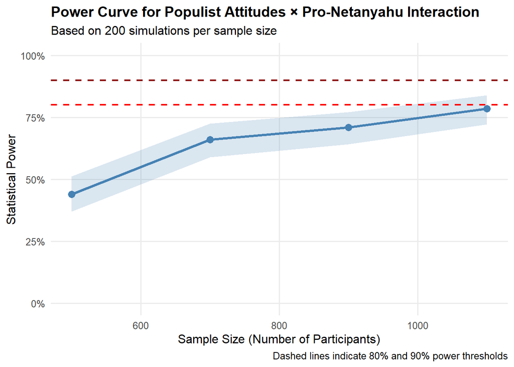

```r
# ============================================================================
# STEP 5: Visualize power curve
# ============================================================================

ggplot2::ggplot(power_curve_results,
                ggplot2::aes(x = n, y = power)) +
  ggplot2::geom_line(size = 1.2, color = "steelblue") +
  ggplot2::geom_point(size = 3, color = "steelblue") +
  ggplot2::geom_ribbon(ggplot2::aes(ymin = lower_ci, ymax = upper_ci),
                       alpha = 0.2, fill = "steelblue") +
  ggplot2::geom_hline(yintercept = 0.80, linetype = "dashed",
                      color = "red", size = 0.8) +
  ggplot2::geom_hline(yintercept = 0.90, linetype = "dashed",
                      color = "darkred", size = 0.8) +
  ggplot2::scale_y_continuous(limits = c(0, 1),
                              labels = scales::percent) +
  ggplot2::labs(
    title = "Power Curve for Populist Attitudes × Pro-Netanyahu Interaction",
    subtitle = "Based on 200 simulations per sample size",
    x = "Sample Size (Number of Participants)",
    y = "Statistical Power",
    caption = "Dashed lines indicate 80% and 90% power thresholds"
  ) +
  ggplot2::theme_minimal(base_size = 12) +
  ggplot2::theme(
    plot.title        = ggplot2::element_text(face = "bold", size = 14),
    panel.grid.minor  = ggplot2::element_blank()
  )
```

```r
# ============================================================================
# STEP 6: Display results table
# ============================================================================

cat("\n=== Complete Power Curve Results (manual_power_sim) ===\n")
```

```
=== Complete Power Curve Results (manual_power_sim) ===
```

```r
print(power_curve_results)
```

```
     n power  lower_ci  upper_ci sig_count
1  500 0.440 0.3700556 0.5117497        88
2  700 0.660 0.5898441 0.7253317       132
3  900 0.710 0.6418125 0.7718430       142
4 1100 0.785 0.7215290 0.8398183       157
```

```r
power_curve_results$power_pct <- paste0(round(power_curve_results$power * 100, 1), "%")
power_curve_results$ci_pct <- paste0(
  "[", round(power_curve_results$lower_ci * 100, 1), "%, ",
  round(power_curve_results$upper_ci * 100, 1), "%]"
)

print(power_curve_results[, c("n", "power_pct", "ci_pct", "sig_count")])
```

```
     n power_pct         ci_pct sig_count
1  500       44%   [37%, 51.2%]        88
2  700       66%   [59%, 72.5%]       132
3  900       71% [64.2%, 77.2%]       142
4 1100     78.5%   [72.2%, 84%]       157
```

```r
# ============================================================================
# STEP 7: Find sample size for target power
# ============================================================================

find_sample_size_for_power <- function(target_power = 0.80) {

  if (max(power_curve_results$power) < target_power) {
    cat("Target power of", target_power, "not achieved in tested range.\n")
    cat("Consider testing larger sample sizes.\n")
    return(NULL)
  }

  below <- power_curve_results[power_curve_results$power < target_power, ]
  above <- power_curve_results[power_curve_results$power >= target_power, ]

  if (nrow(below) == 0) {
    return(min(power_curve_results$n))
  }

  n_below      <- max(below$n)
  n_above      <- min(above$n)
  power_below  <- below$power[below$n == n_below]
  power_above  <- above$power[above$n == n_above]

  n_target <- n_below +
    (target_power - power_below) / (power_above - power_below) * (n_above - n_below)

  ceiling(n_target)
}

n_for_80 <- find_sample_size_for_power(0.80)
```

```
Target power of 0.8 not achieved in tested range.
Consider testing larger sample sizes.
```

```r
cat("\n=== Recommended Sample Sizes (manual_power_sim) ===\n")
```

```
=== Recommended Sample Sizes (manual_power_sim) ===
```

```r
cat("For 80% power:", n_for_80, "participants\n")
```

```
For 80% power: participants
```

```r
manual_power_sim <- function(pilot_model,
                             beta_target,
                             n_participants,
                             n_sims = 200,
                             alpha_one_sided = 0.05,
                             seed = 2025) {

  if (!is.null(seed)) base::set.seed(seed)

  # Original data and variance components from pilot_model
  original_data <- stats::model.frame(pilot_model)

  vc      <- lme4::VarCorr(pilot_model)
  tau2    <- as.numeric(vc$pid)
  sigma2  <- stats::sigma(pilot_model)^2

  # Interaction term
  inter_name <- "populist_attitudes:pro_netanyahu1"
  beta_int   <- beta_target[inter_name]

  if (beta_int < 0) {
    direction <- "negative"
  } else if (beta_int > 0) {
    direction <- "positive"
  } else {
    direction <- "zero"
    message("Warning: interaction beta is 0; falling back to two-sided test.")
  }

  cat("Target interaction beta:", round(beta_int, 3),
      " (direction:", direction, ")\n")
  cat("Using one-tailed alpha =", alpha_one_sided, "\n")
  cat("Running", n_sims, "simulations at N =", n_participants, "...\n")

  significant_count <- 0
  p_values          <- numeric(n_sims)

  for (i in seq_len(n_sims)) {

    # 1. Resample participants
    sampled_pids <- base::sample(unique(original_data$pid),
                                 size = n_participants,
                                 replace = TRUE)

    sim_data <- do.call(rbind, lapply(seq_len(n_participants), function(j) {
      pid_data     <- original_data[original_data$pid == sampled_pids[j], ]
      pid_data$pid <- factor(j)
      pid_data
    }))

    # 2. Simulate from target model
    u_id <- stats::rnorm(n_participants, mean = 0, sd = sqrt(tau2))
    u    <- u_id[sim_data$pid]

    e <- stats::rnorm(nrow(sim_data), mean = 0, sd = sqrt(sigma2))

    X <- stats::model.matrix(~ populist_attitudes * pro_netanyahu, data = sim_data)
    beta_sim <- beta_target[colnames(X)]

    eta <- as.numeric(X %*% beta_sim) + as.numeric(u) + e
    sim_data$sim_response <- eta

    # 3. Fit model and test interaction
    fit_model <- lme4::lmer(
      sim_response ~ populist_attitudes * pro_netanyahu + (1 | pid),
      data = sim_data
    )

    coef_sum <- summary(fit_model)$coefficients
    t_val    <- coef_sum[inter_name, "t value"]

    df_approx <- nrow(sim_data) - nrow(coef_sum)

    # ONE-TAILED p based on direction
    if (direction == "negative") {
      p_one_sided <- stats::pt(t_val, df_approx, lower.tail = TRUE)
    } else if (direction == "positive") {
      p_one_sided <- stats::pt(t_val, df_approx, lower.tail = FALSE)
    } else {
      p_one_sided <- 2 * stats::pt(abs(t_val), df_approx, lower.tail = FALSE)
    }

    p_values[i] <- p_one_sided

    if (p_one_sided < alpha_one_sided) {
      significant_count <- significant_count + 1
    }

    if (i %% 20 == 0) {
      cat("  Completed", i, "of", n_sims, "simulations\n")
    }
  }

  power_estimate <- significant_count / n_sims
  ci <- stats::binom.test(significant_count, n_sims)$conf.int

  list(
    n          = n_participants,
    power      = power_estimate,
    ci_lower   = ci[1],
    ci_upper   = ci[2],
    sig_count  = significant_count,
    total_sims = n_sims,
    p_values   = p_values,
    alpha_one_sided = alpha_one_sided,
    beta_target     = beta_int
  )
}




# ============================================================================
# STEP 3: Run power analysis for a single sample size
# ============================================================================

# Example: test at N = 400 (uses pilot_model + beta_target from previous chunk)
power_400 <- manual_power_sim(
  pilot_model   = pilot_model,
  beta_target   = beta_target,
  n_participants = 400,
  n_sims        = 200,
  alpha         = 0.05,
  seed          = 2025
)
```

```
Target interaction beta: -0.15  (direction: negative )
Using one-tailed alpha = 0.05
Running 200 simulations at N = 400 ...
  Completed 20 of 200 simulations
  Completed 40 of 200 simulations
  Completed 60 of 200 simulations
  Completed 80 of 200 simulations
  Completed 100 of 200 simulations
  Completed 120 of 200 simulations
  Completed 140 of 200 simulations
  Completed 160 of 200 simulations
  Completed 180 of 200 simulations
  Completed 200 of 200 simulations
```

```r
cat("\n=== Power Results at N = 400 ===\n")
```

```
=== Power Results at N = 400 ===
```

```r
cat("Power:", round(power_400$power * 100, 1), "%\n")
```

```
Power: 52.5 %
```

```r
cat("95% CI: [", round(power_400$ci_lower * 100, 1), "%, ",
    round(power_400$ci_upper * 100, 1), "%]\n", sep = "")
```

```
95% CI: [45.3%, 59.6%]
```

```r
cat("Significant results:", power_400$sig_count, "out of", power_400$total_sims, "\n")
```

```
Significant results: 105 out of 200
```

```r
# ============================================================================
# STEP 4: Run power curve across multiple sample sizes
# ============================================================================

sample_sizes <- c(500, 700, 900, 1100)

power_curve_results <- data.frame(
  n        = integer(),
  power    = numeric(),
  lower_ci = numeric(),
  upper_ci = numeric(),
  sig_count = integer()
)

cat("\n=== Running Power Curve Analysis (manual_power_sim) ===\n")
```

```
=== Running Power Curve Analysis (manual_power_sim) ===
```

```r
cat("Testing sample sizes:", paste(sample_sizes, collapse = ", "), "\n\n")
```

```
Testing sample sizes: 500, 700, 900, 1100
```

```r
for (n in sample_sizes) {
  cat("\n--- Testing N =", n, "---\n")

  result <- manual_power_sim(
    pilot_model    = pilot_model,
    beta_target    = beta_target,
    n_participants = n,
    n_sims         = 200,
    alpha          = 0.05,
    seed           = 2025 + n
  )

  power_curve_results <- rbind(power_curve_results, data.frame(
    n        = result$n,
    power    = result$power,
    lower_ci = result$ci_lower,
    upper_ci = result$ci_upper,
    sig_count = result$sig_count
  ))

  cat("Power:", round(result$power * 100, 1), "%\n")
}
```

```
--- Testing N = 500 ---
Target interaction beta: -0.15  (direction: negative )
Using one-tailed alpha = 0.05
Running 200 simulations at N = 500 ...
  Completed 20 of 200 simulations
  Completed 40 of 200 simulations
  Completed 60 of 200 simulations
  Completed 80 of 200 simulations
  Completed 100 of 200 simulations
  Completed 120 of 200 simulations
  Completed 140 of 200 simulations
  Completed 160 of 200 simulations
  Completed 180 of 200 simulations
  Completed 200 of 200 simulations
Power: 58.5 %

--- Testing N = 700 ---
Target interaction beta: -0.15  (direction: negative )
Using one-tailed alpha = 0.05
Running 200 simulations at N = 700 ...
  Completed 20 of 200 simulations
  Completed 40 of 200 simulations
  Completed 60 of 200 simulations
  Completed 80 of 200 simulations
  Completed 100 of 200 simulations
  Completed 120 of 200 simulations
  Completed 140 of 200 simulations
  Completed 160 of 200 simulations
  Completed 180 of 200 simulations
  Completed 200 of 200 simulations
Power: 74.5 %

--- Testing N = 900 ---
Target interaction beta: -0.15  (direction: negative )
Using one-tailed alpha = 0.05
Running 200 simulations at N = 900 ...
  Completed 20 of 200 simulations
  Completed 40 of 200 simulations
  Completed 60 of 200 simulations
  Completed 80 of 200 simulations
```

[output cut: 8 more lines]

```
--- Testing N = 1100 ---
Target interaction beta: -0.15  (direction: negative )
Using one-tailed alpha = 0.05
Running 200 simulations at N = 1100 ...
  Completed 20 of 200 simulations
  Completed 40 of 200 simulations
  Completed 60 of 200 simulations
  Completed 80 of 200 simulations
  Completed 100 of 200 simulations
  Completed 120 of 200 simulations
  Completed 140 of 200 simulations
  Completed 160 of 200 simulations
  Completed 180 of 200 simulations
  Completed 200 of 200 simulations
Power: 86 %
```

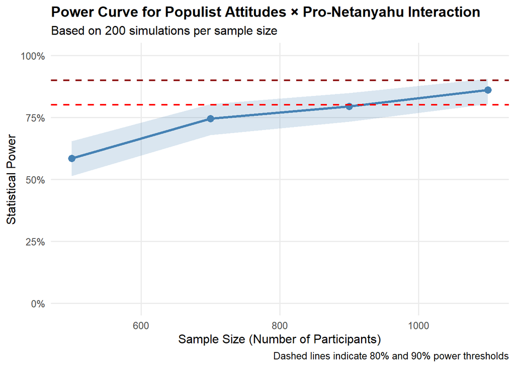

```r
# ============================================================================
# STEP 5: Visualize power curve
# ============================================================================

ggplot2::ggplot(power_curve_results,
                ggplot2::aes(x = n, y = power)) +
  ggplot2::geom_line(size = 1.2, color = "steelblue") +
  ggplot2::geom_point(size = 3, color = "steelblue") +
  ggplot2::geom_ribbon(ggplot2::aes(ymin = lower_ci, ymax = upper_ci),
                       alpha = 0.2, fill = "steelblue") +
  ggplot2::geom_hline(yintercept = 0.80, linetype = "dashed",
                      color = "red", size = 0.8) +
  ggplot2::geom_hline(yintercept = 0.90, linetype = "dashed",
                      color = "darkred", size = 0.8) +
  ggplot2::scale_y_continuous(limits = c(0, 1),
                              labels = scales::percent) +
  ggplot2::labs(
    title = "Power Curve for Populist Attitudes × Pro-Netanyahu Interaction",
    subtitle = "Based on 200 simulations per sample size",
    x = "Sample Size (Number of Participants)",
    y = "Statistical Power",
    caption = "Dashed lines indicate 80% and 90% power thresholds"
  ) +
  ggplot2::theme_minimal(base_size = 12) +
  ggplot2::theme(
    plot.title        = ggplot2::element_text(face = "bold", size = 14),
    panel.grid.minor  = ggplot2::element_blank()
  )
```

```r
# ============================================================================
# STEP 6: Display results table
# ============================================================================

cat("\n=== Complete Power Curve Results (manual_power_sim) ===\n")
```

```
=== Complete Power Curve Results (manual_power_sim) ===
```

```r
print(power_curve_results)
```

```
     n power  lower_ci  upper_ci sig_count
1  500 0.585 0.5133753 0.6540663       117
2  700 0.745 0.6787246 0.8038592       149
3  900 0.795 0.7323461 0.8486894       159
4 1100 0.860 0.8040547 0.9049125       172
```

```r
power_curve_results$power_pct <- paste0(round(power_curve_results$power * 100, 1), "%")
power_curve_results$ci_pct <- paste0(
  "[", round(power_curve_results$lower_ci * 100, 1), "%, ",
  round(power_curve_results$upper_ci * 100, 1), "%]"
)

print(power_curve_results[, c("n", "power_pct", "ci_pct", "sig_count")])
```

```
     n power_pct         ci_pct sig_count
1  500     58.5% [51.3%, 65.4%]       117
2  700     74.5% [67.9%, 80.4%]       149
3  900     79.5% [73.2%, 84.9%]       159
4 1100       86% [80.4%, 90.5%]       172
```

```r
# ============================================================================
# STEP 7: Find sample size for target power
# ============================================================================

find_sample_size_for_power <- function(target_power = 0.80) {

  if (max(power_curve_results$power) < target_power) {
    cat("Target power of", target_power, "not achieved in tested range.\n")
    cat("Consider testing larger sample sizes.\n")
    return(NULL)
  }

  below <- power_curve_results[power_curve_results$power < target_power, ]
  above <- power_curve_results[power_curve_results$power >= target_power, ]

  if (nrow(below) == 0) {
    return(min(power_curve_results$n))
  }

  n_below      <- max(below$n)
  n_above      <- min(above$n)
  power_below  <- below$power[below$n == n_below]
  power_above  <- above$power[above$n == n_above]

  n_target <- n_below +
    (target_power - power_below) / (power_above - power_below) * (n_above - n_below)

  ceiling(n_target)
}

n_for_80 <- find_sample_size_for_power(0.80)

cat("\n=== Recommended Sample Sizes (manual_power_sim) ===\n")
```

```
=== Recommended Sample Sizes (manual_power_sim) ===
```

```r
cat("For 80% power:", n_for_80, "participants\n")
```

```
For 80% power: 916 participants
```